# JensenNarleskiSaraf_proj

Samantha Jensen, Jaclyn Narleski, Akanksha Saraf

2025-03-12

Is there a significant difference between exposures for pollutants based on activity? recreational, commercial, industrial, agricultural comparing specific pollutants (ANOVA) comparing the NC air quality levels for exposure to the real levels that we are seeing.

next steps: - picking pollutants (2) (formaldehyde, diesel PM, maybe another) - sorting columns into categories - find NC air quality standards for selected pollutants

Unemployment Data: https://hdpulse.nimhd.nih.gov/data-portal/social/table?age=916&age_options=age25_1&demo=00012&demo_options=education_3&race=00&race_options=race_7&sex=0&sex_options=sexboth_1&socialtopic=090&socialtopic_options=social_6&statefips=37&statefips_options=area_states

Population Density: https://beautifydata.com/united-states-population/census/2020/population-density-by-county/north-carolina

Income: https://hdpulse.nimhd.nih.gov/data-portal/social/table?age=001&age_options=ageall_1&demo=00010&demo_options=income_3&race=00&race_options=race_7&sex=0&sex_options=sexboth_1&socialtopic=030&socialtopic_options=social_6&statefips=37&statefips_options=area_states # Setup

```r
# Load packages
library(tidyverse)
library(here)
library(knitr)
library(readxl)
library(patchwork)

# Load data
exposure <- read.csv("ExposureConcentrationsRaw.csv")
# Loading in dataset with urban/rural classification for each county in NC
urban_rural <- read_excel("urban_rural.xlsx")
# dataset with unemployment and median family income
census <- read_excel("census_combined.xlsx")
```

# Methods

## Data Wrangling & Tidying

The raw dataset for exposure concentrations of air toxics in North Carolina contains the following information for each measurement of exposure: EPA region, county, FIPS code, FIPS tract, population, pollutant name, total exposure concentration, and several different sources that contributed to that total exposure concentration. The EPA divides these sources into different categories, as displayed below in Figure 1:

Figure 1: National Air Toxics Assessment (NATA) Emission Sources

| On Road | Non-Road | Non-Point Stationary |
| --- | --- | --- |
| Light Duty Gas On-Network | Recreational & Pleasure Craft | Industrial |
| Light Duty Diesel On-Network | Construction | Oil & Gas |
| Light Duty Gas Off-Network | Commercial Lawn & Garden | Commercial Cooking |
| Light Duty Diesel Off-Network | Residential Lawn & Garden | Solvents and Coatings |
| Heavy Duty Gas On-Network | Agricultural Equipment | Bulk Terminal Storage & Transfer (stage 1) |
| Heavy Duty Diesel On-Network | Commercial Equipment | Fuel Combustion (except residential wood) |
| Heavy Duty Gas Off-Network | Commercial Marine Vessel C1/C2 | Waste Disposal |
| Heavy Duty Diesel Off-Network | Commercial Marine Vessel C3 | Agricultural Livestock |
| Heavy Duty Diesel Hoteling | Commercial Marine Vessels Underway | Miscellaneous Nonindustrial |
| Refueling | Locomotives |  |
|  | Airports (point source) |  |
|  | Railroads (point source) |  |
|  | All Other Non-Road Equipment |  |

“On Road” and “Non-Road” refer to mobile sources that emit air pollutants. “On Road” references mobile sources on the U.S. highway system that transport either passengers or freight. This includes passenger cars and light trucks (i.e. “light duty vehicles”); semi-trucks, RVs, delivery trucks, and buses (i.e. “heavy duty vehicles”); and each type of vehicle is separated by what type of fuel they use, gas or diesel. These types of vehicles are further categorized to “on-netork,” or in motion, and “off-netork,” or idle, as well as “refueling,” or any vapor/spillage from fueling refills, or “hoteling,” which is specific to heavy duty vehicles idling.

“Non-Road” references mobile sources that aren’t on the U.S. highway system. This can range from recreational vehicles like snowcraft, boats, ATVs, dirt bikes to industrial/agricultural equipment and other forms of transportation like airports, railines (“railroads” and “locomotives”), and marine vessels. Marine vessels are categorized by engine size, with C1 and C2 considered smaller and C3 considered larger, as well as by “underway”, or not anchored.

The Exposure dataset was subsetted to include activities that fell into the “On Road” and “Non Road” categories. From there, three datasets were created for the three pollutants of focus: Formaldehyde, Benzene and Diesel. The data wrangling for these three pollutants was identical. The exposure for each activity and the total exposure were summed in order to get have just one value for each column for the 100 counties in North Carolina. From here, we were able to join demographic data to each pollutant data set. The census dataset was created in Excel and has columns containing county wide unemployment rates, population density and Median Family Income. Additionally, a column was joined to each data set with the designation of each column as “Urban” or “Rural.” This designation was obtained from the North Carolina Department of Health and Human Services, which listed 46 urban counties and 54 rural counties.

In order to answer our research questions, multiple linear models were created for each of the three pollutants. The methods for each analysis are outlined below:

### Data Tidying & Wrangling Code

#### Exposure Data

```r
# Select columns and rename for clarity
exposure_df <- exposure %>%
  select(County, Population, Pollutant.Name, Total.Exposure.Conc,
         OR.LightDuty.OffNetwork.Gas.Exposure.Conc,
         OR.LightDuty.OffNetwork.Diesel.Exposure.Conc,
         OR.HeavyDuty.OffNetwork.Gas.Exposure.Conc,
         OR.HeavyDuty.OffNetwork.Diesel.Exposure.Conc,
         OR.HeavyDuty.OnNetwork.Diesel.Exposure.Conc,
         OR.LightDuty.OnNetwork.Gas.Exposure.Conc,
         OR.LightDuty.OnNetwork.Diesel.Exposure.Conc,
         OR.HeavyDuty.OnNetwork.Gas.Exposure.Conc,
         OR.HeavyDuty.Hoteling.Exposure.Conc,
         OR.Refueling.Exposure.Conc,
         NR.Recreational.inc.PleasureCraft.Exposure.Conc,
         NR.Construction.Exposure.Conc,
         NR.Agriculture.Exposure.Conc,
         NR.CommercialEquipment.Exposure.Conc,
         NR.Locomotives.Exposure.Conc,
         NR.Point.Airports.Exposure.Conc,
         NR..Point.Railyards.Exposure.Conc) %>%
  rename("OR.Light.Off.Gas" = OR.LightDuty.OffNetwork.Gas.Exposure.Conc,
         "OR.Light.Off.Diesel" = OR.LightDuty.OffNetwork.Diesel.Exposure.Conc,
         "OR.Heavy.Off.Gas" = OR.HeavyDuty.OffNetwork.Gas.Exposure.Conc,
         "OR.Heavy.Off.Diesel" = OR.HeavyDuty.OffNetwork.Diesel.Exposure.Conc,
         "OR.Light.On.Gas" = OR.LightDuty.OnNetwork.Gas.Exposure.Conc,
         "OR.Light.On.Diesel" = OR.LightDuty.OnNetwork.Diesel.Exposure.Conc,
         "OR.Heavy.On.Gas" = OR.HeavyDuty.OnNetwork.Gas.Exposure.Conc,
         "OR.Heavy.On.Diesel" = OR.HeavyDuty.OnNetwork.Diesel.Exposure.Conc,
         "OR.Heavy.Idling" = OR.HeavyDuty.Hoteling.Exposure.Conc,
         "OR.Refueling" = OR.Refueling.Exposure.Conc,
         "NR.Recreational.Vehicles" =
           NR.Recreational.inc.PleasureCraft.Exposure.Conc,
         "NR.Construction" = NR.Construction.Exposure.Conc,
         "NR.Agriculture" = NR.Agriculture.Exposure.Conc,
         "NR.Commerical.Equip" = NR.CommercialEquipment.Exposure.Conc,
         "NR.Locomotives" = NR.Locomotives.Exposure.Conc,
         "NR.Airpoints" = NR.Point.Airports.Exposure.Conc,
         "NR.Railyards" = NR..Point.Railyards.Exposure.Conc) %>%
  mutate(County = as.factor(County))
```

#### Urban/Rural & Census Data

```r
# Making rural/urban data into a factor
urban_rural$URBAN_RURAL <- as.factor(urban_rural$URBAN_RURAL)
# Filtering census data
census_select <- census %>%
  select(County,
         `Median Family Income (Dollars)`:
           `Population Density (Persons Per SqMile)`)
# Making income a numeric class
census_select$`Median Family Income (Dollars)` <- as.numeric(gsub("[^0-9]", "",
                                census_select$`Median Family Income (Dollars)`))
census_select$`Population Density (Persons Per SqMile)` <-  as.numeric(gsub("[^0-9.]", "", census_select$`Population Density (Persons Per SqMile)`))
```

#### Formaldehyde Data

```r
formaldehyde <- exposure_df %>%
  filter(Pollutant.Name == "FORMALDEHYDE") %>%
  group_by(County) %>%
  summarise(across(where(is.numeric), sum, na.rm = TRUE)) %>%
  ungroup()
# subtracting entire state
formaldehyde <- formaldehyde[-34,]
# adding columns that sum all of the nonroad and onroad exposures for each county
# formaldehyde dataframe still has all of the exposure activities so it can be
# used for other analysis if we want
formaldehyde <- formaldehyde %>%
  mutate(Onroad_total = select(., OR.Light.Off.Gas:OR.Refueling) %>%
      rowSums(na.rm = TRUE)) %>%
  mutate(Nonroad_total = select(., NR.Recreational.Vehicles:NR.Railyards) %>%
      rowSums(na.rm = TRUE))

# joining urban/rural column
formaldehyde_select <- left_join(formaldehyde, urban_rural, by = "County")
# selecting necessary columns
formaldehyde_select <- formaldehyde_select %>%
  select(County, Population, Total.Exposure.Conc, Onroad_total:URBAN_RURAL)
# joining with census data
formaldehyde_complete <- left_join(formaldehyde_select,
                                   census_select, by = "County")
# making county into factor
formaldehyde_complete$County <- as.factor(formaldehyde_complete$County)
```

#### Benzene Data

```r
benzene <- exposure_df %>%
  filter(Pollutant.Name == "BENZENE") %>%
  group_by(County) %>%
  summarise(across(where(is.numeric), sum, na.rm = TRUE)) %>%
  ungroup()
# subtracting entire state
benzene <- benzene[-34,]
# adding columns that sum all of the nonroad and onroad exposures for each county
benzene <- benzene %>%
  mutate(Onroad_total = select(., OR.Light.Off.Gas:OR.Refueling) %>%
           rowSums(na.rm = TRUE)) %>%
  mutate(Nonroad_total = select(., NR.Recreational.Vehicles:NR.Railyards) %>%
           rowSums(na.rm = TRUE))

# joining urban/rural column
benzene_select <- left_join(benzene, urban_rural, by = "County")
# selecting necessary columns
benzene_select <- benzene_select %>%
  select(County, Population, Total.Exposure.Conc, Onroad_total:URBAN_RURAL)
# joining with census data
benzene_complete <- left_join(benzene_select, census_select, by = "County")
# making county into factor
benzene_complete$County <- as.factor(benzene_complete$County)
```

#### Diesel Data

```r
## Diesel
diesel <- exposure_df %>%
  filter(Pollutant.Name == "DIESEL PM") %>%
  group_by(County) %>%
  summarise(across(where(is.numeric), sum, na.rm = TRUE)) %>%
  ungroup()
# subtracting entire state
diesel <- diesel[-34,]
# adding columns that sum all of the nonroad and onroad exposures for each county
diesel <- diesel %>%
  mutate(
    Onroad_total =
      select(., OR.Light.Off.Gas:OR.Refueling) %>%
      rowSums(na.rm = TRUE)) %>%
  mutate(Nonroad_total = select(., NR.Recreational.Vehicles:NR.Railyards) %>%
           rowSums(na.rm = TRUE))

# joining urban/rural column
diesel_select <- left_join(diesel, urban_rural, by = "County")
# selecting necessary columns
diesel_select <- diesel_select %>%
  select(County, Population, Total.Exposure.Conc, Onroad_total:URBAN_RURAL)

# joining with census data
diesel_complete <- left_join(diesel_select, census_select, by = "County")
diesel_complete$County <- as.factor(diesel_complete$County)

## Can still join the cancer data in if we want to
```

# Analysis

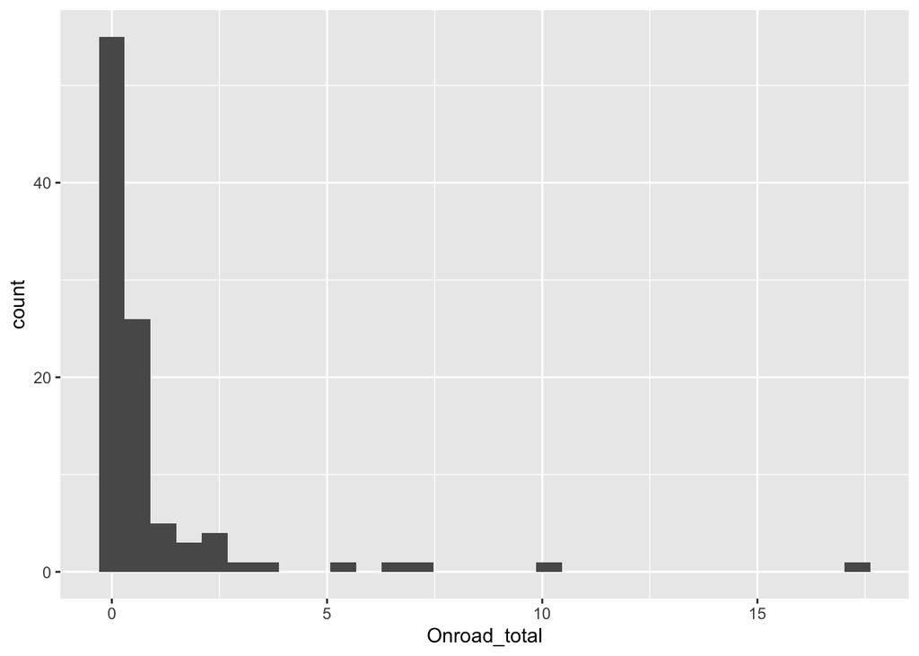

```r
formaldehyde_onroad <- formaldehyde_complete %>%
  ggplot(aes(x = Onroad_total)) +
  geom_histogram()

formaldehyde_onroad
```

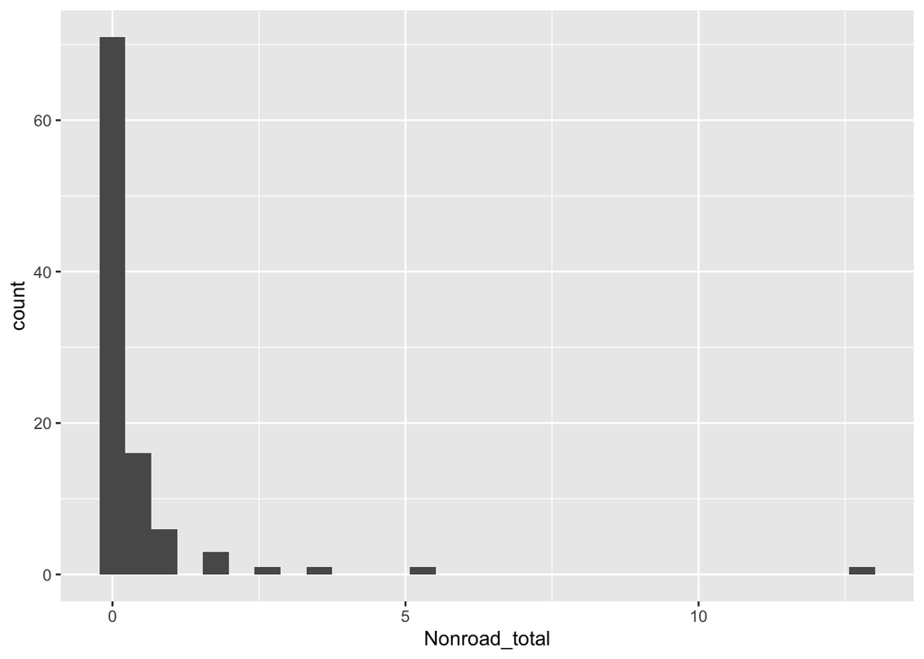

```r
formaldehyde_nonroad <- formaldehyde_complete %>%
  ggplot(aes(x = Nonroad_total)) +
  geom_histogram()

formaldehyde_nonroad
```

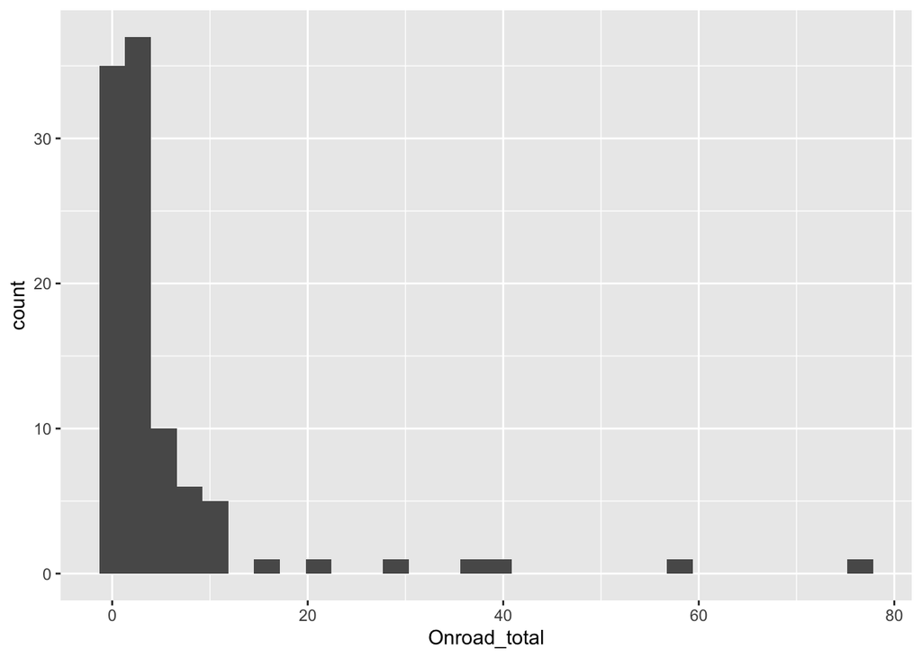

```r
benzene_onroad <- benzene_complete %>%
  ggplot(aes(x = Onroad_total)) +
  geom_histogram()

benzene_onroad
```

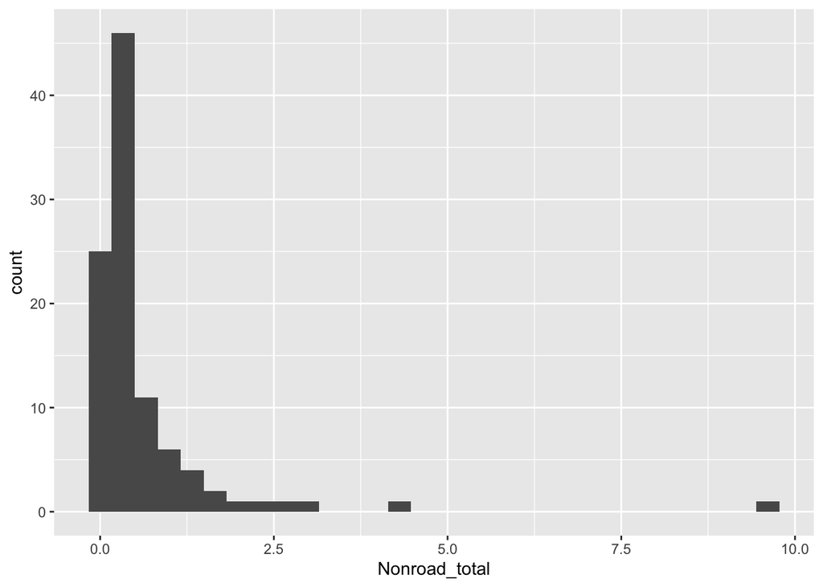

```r
benzene_nonroad <- benzene_complete %>%
  ggplot(aes(x = Nonroad_total)) +
  geom_histogram()

benzene_nonroad
```

#### Formaldehyde Model

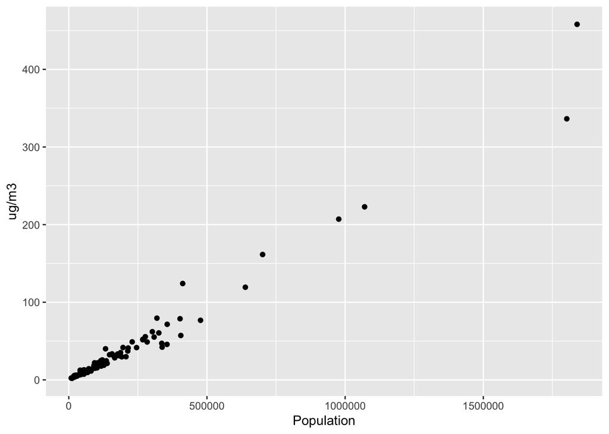

```r
# Visualizing the relationship between response and descriptor variables
(scatter_population <- ggplot(formaldehyde_complete,
                              aes(x = Population, y = Total.Exposure.Conc)) +
  geom_point() +
   labs(x = "Population",
        y = "ug/m3"))
```

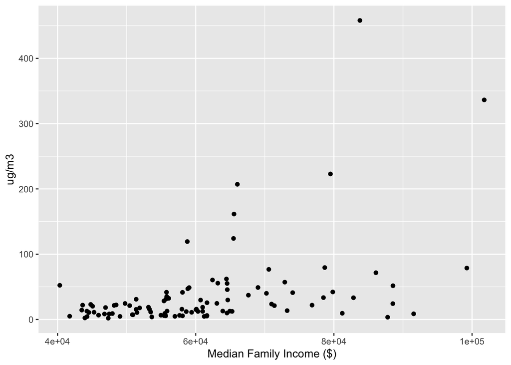

```r
(scatter_income <- ggplot(formaldehyde_complete,
                          aes(x = `Median Family Income (Dollars)`,
                              y = Total.Exposure.Conc)) +
    geom_point() +
    labs(x = "Median Family Income ($)",
        y = "ug/m3"))
```

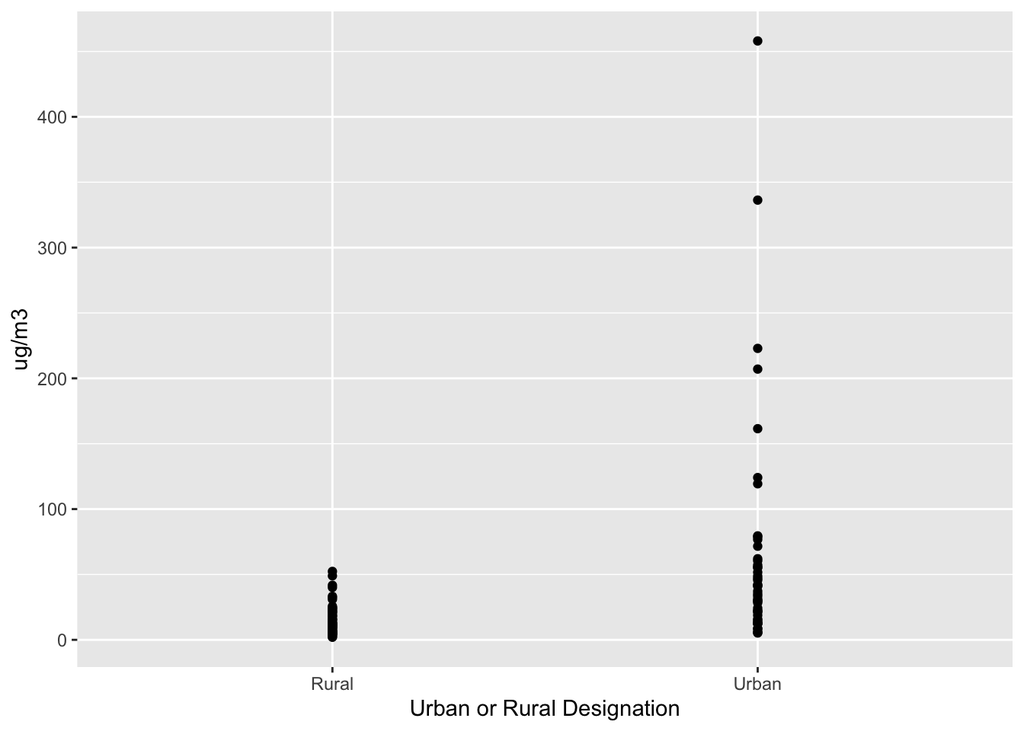

```r
(scatter_urban <- ggplot(formaldehyde_complete,
                         aes(x = URBAN_RURAL, y = Total.Exposure.Conc)) +
    geom_point() +
    labs(x = "Urban or Rural Designation",
        y = "ug/m3"))
```

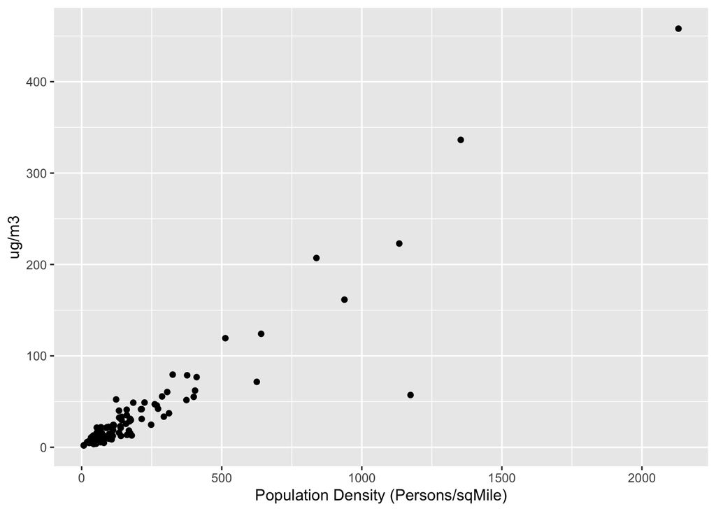

```r
(scatter_density <- ggplot(formaldehyde_complete,
                           aes(x = `Population Density (Persons Per SqMile)`,
                               y = Total.Exposure.Conc)) +
    geom_point() +
    labs(x = "Population Density (Persons/sqMile)",
        y = "ug/m3"))
```